# Economic History - Assignment 2

Lionel Chambon

2024-11-13

## Part A

```r
jst = read_xlsx("C:/Users/etien/OneDrive/Documents/GitHub/Econ-History/A2/JSTdatasetR6.xlsx")

tibble(jst)
```

```
## # A tibble: 2,718 × 59
##     year country   iso     ifs   pop rgdpmad rgdpbarro rconsbarro   gdp    iy
##    <dbl> <chr>     <chr> <dbl> <dbl>   <dbl>     <dbl>      <dbl> <dbl> <dbl>
##  1  1870 Australia AUS     193  1775   3273.      13.8       21.4  209. 0.109
##  2  1871 Australia AUS     193  1675   3299.      13.9       19.9  212. 0.105
##  3  1872 Australia AUS     193  1722   3553.      15.0       21.1  227. 0.130
##  4  1873 Australia AUS     193  1769   3824.      16.2       23.3  267. 0.125
##  5  1874 Australia AUS     193  1822   3835.      16.3       23.5  288. 0.142
##  6  1875 Australia AUS     193  1874   4138.      17.6       25.7  301. 0.161
##  7  1876 Australia AUS     193  1929   4007.      17.0       24.8  311. 0.168
##  8  1877 Australia AUS     193  1995   4036.      17.1       25.2  314. 0.210
##  9  1878 Australia AUS     193  2062   4277.      18.2       26.6  324. 0.181
## 10  1879 Australia AUS     193  2127   4205.      17.9       26.5  334. 0.162
## # ℹ 2,708 more rows
## # ℹ 49 more variables: cpi <dbl>, ca <dbl>, imports <dbl>, exports <dbl>,
## #   narrowm <dbl>, money <dbl>, stir <dbl>, ltrate <dbl>, hpnom <dbl>,
## #   unemp <dbl>, wage <dbl>, debtgdp <dbl>, revenue <dbl>, expenditure <dbl>,
## #   xrusd <dbl>, tloans <dbl>, tmort <dbl>, thh <dbl>, tbus <dbl>, bdebt <dbl>,
## #   lev <dbl>, ltd <dbl>, noncore <dbl>, crisisJST <dbl>, crisisJST_old <dbl>,
## #   peg <dbl>, peg_strict <dbl>, peg_type <chr>, peg_base <chr>, …
```

```r
names(jst)
```

```
##  [1] "year"                     "country"
##  [3] "iso"                      "ifs"
##  [5] "pop"                      "rgdpmad"
##  [7] "rgdpbarro"                "rconsbarro"
##  [9] "gdp"                      "iy"
## [11] "cpi"                      "ca"
## [13] "imports"                  "exports"
## [15] "narrowm"                  "money"
## [17] "stir"                     "ltrate"
## [19] "hpnom"                    "unemp"
## [21] "wage"                     "debtgdp"
## [23] "revenue"                  "expenditure"
## [25] "xrusd"                    "tloans"
## [27] "tmort"                    "thh"
## [29] "tbus"                     "bdebt"
## [31] "lev"                      "ltd"
## [33] "noncore"                  "crisisJST"
## [35] "crisisJST_old"            "peg"
## [37] "peg_strict"               "peg_type"
## [39] "peg_base"                 "JSTtrilemmaIV"
## [41] "eq_tr"                    "housing_tr"
## [43] "bond_tr"                  "bill_rate"
## [45] "rent_ipolated"            "housing_capgain_ipolated"
## [47] "housing_capgain"          "housing_rent_rtn"
## [49] "housing_rent_yd"          "eq_capgain"
## [51] "eq_dp"                    "eq_capgain_interp"
## [53] "eq_tr_interp"             "eq_dp_interp"
## [55] "bond_rate"                "eq_div_rtn"
## [57] "capital_tr"               "risky_tr"
## [59] "safe_tr"
```

### Model Estimation

First, we have to generate the log changes and the lags of the private credit supply variable.

```r
jst <- jst %>%
  arrange(country, year) %>%
  group_by(country) %>%
  mutate(
    rcredit = (tloans/cpi),
    rgdp = (gdp/cpi),
    log_credit = log(rcredit),
    d_log_credit = log_credit - lag(log_credit, 1),
    credit_lag1 = lag(d_log_credit, 1),
    credit_lag2 = lag(d_log_credit, 2),
    credit_lag3 = lag(d_log_credit, 3),
    credit_lag4 = lag(d_log_credit, 4),
    credit_lag5 = lag(d_log_credit, 5)
  ) %>%
  ungroup()
```

Next, estimating the logit model:

```r
logit_a = feglm(crisisJST ~ credit_lag1 + credit_lag2 + credit_lag3 + credit_lag4 + credit_lag5 | country,
                data = jst,
                family = binomial(link = "logit"))
```

```
## NOTE: 400 observations removed because of NA values (LHS: 50, RHS: 400).
```

Note that R automatically removes NA observations of the lags.

Displaying results:

```r
summary(logit_a)
```

```
## GLM estimation, family = binomial(link = "logit"), Dep. Var.: crisisJST
## Observations: 2,318
## Fixed-effects: country: 18
## Standard-errors: Clustered (country)
##              Estimate Std. Error   z value   Pr(>|z|)
## credit_lag1  0.411930   1.231819  0.334408 0.73807185
## credit_lag2  6.805724   1.644521  4.138424 0.00003497 ***
## credit_lag3 -0.499728   0.759789 -0.657720 0.51071839
## credit_lag4  0.025711   1.096636  0.023445 0.98129514
## credit_lag5  1.136693   0.786573  1.445121 0.14842389
## ---
## Signif. codes:  0 '***' 0.001 '**' 0.01 '*' 0.05 '.' 0.1 ' ' 1
## Log-Likelihood: -298.9   Adj. Pseudo R2: 0.010384
##            BIC:  776.0     Squared Cor.: 0.033239
```

This tells us that only the second lag of private credit supply is individually significant in this specification. This is consistent with the results from Schularick and Taylor (2012).

Now, conducting the joint tests:

```r
hypothesis1 <- c("credit_lag1 = 0", "credit_lag2 = 0", "credit_lag3 = 0", "credit_lag4 = 0", "credit_lag5 = 0")

wald1 <- linearHypothesis(logit_a, hypothesis1)

print(wald1)
```

```
## Linear hypothesis test
##
## Hypothesis:
## credit_lag1 = 0
## credit_lag2 = 0
## credit_lag3 = 0
## credit_lag4 = 0
## credit_lag5 = 0
##
## Model 1: restricted model
## Model 2: crisisJST ~ credit_lag1 + credit_lag2 + credit_lag3 + credit_lag4 +
##     credit_lag5 | country
##
##   Res.Df Df  Chisq Pr(>Chisq)
## 1   2300
## 2   2295  5 51.303  7.498e-10 ***
## ---
## Signif. codes:  0 '***' 0.001 '**' 0.01 '*' 0.05 '.' 0.1 ' ' 1
```

The p-value is well below $0.05$, so we can reject the null hypothesis that lags of log changes in credit supply are jointly insignificant.

Next, we load the BVX crisis data.

```r
###CHANGE
bvx <- read_dta("C:/Users/etien/OneDrive/Documents/GitHub/Econ-History/A2/BVX replication kit/BVX replication kit/data/additional data/Narrative Crisis List, Panics List, and BVX List.dta")
```

This looks a bit messy to merge. First, I identify all crisis years by country, before expanding the time series to match the JST dataset and creating an appropriate BVX dummy.

```r
bvx_by_country <- bvx %>%
  filter(!is.na(revised)) %>%
  group_by(country) %>%
  summarize(Crisis_Years = list(revised))

print(bvx_by_country)
```

```
## # A tibble: 45 × 2
##    country   Crisis_Years
##    <chr>     <list>
##  1 Argentina <dbl [9]>
##  2 Australia <dbl [3]>
##  3 Austria   <dbl [5]>
##  4 Belgium   <dbl [8]>
##  5 Brazil    <dbl [7]>
##  6 Canada    <dbl [3]>
##  7 Chile     <dbl [8]>
##  8 Colombia  <dbl [3]>
##  9 Czech     <dbl [3]>
## 10 Denmark   <dbl [7]>
## # ℹ 35 more rows
```

```r
year_range <- 1870:2020

bvx_ts <- bvx_by_country %>%
  select(country) %>%
  distinct() %>%
  expand(country, year = year_range) %>%
  left_join(bvx_by_country, by = "country") %>%
  rowwise() %>%
  mutate(BVX = ifelse(year %in% unlist(Crisis_Years), 1, 0)) %>%
  ungroup() %>%
  select(country, year, BVX)

print(bvx_ts)
```

```
## # A tibble: 6,795 × 3
##    country    year   BVX
##    <chr>     <int> <dbl>
##  1 Argentina  1870     0
##  2 Argentina  1871     0
##  3 Argentina  1872     0
##  4 Argentina  1873     0
##  5 Argentina  1874     0
##  6 Argentina  1875     0
##  7 Argentina  1876     0
##  8 Argentina  1877     0
##  9 Argentina  1878     0
## 10 Argentina  1879     0
## # ℹ 6,785 more rows
```

I check by hand for Argentina and Australia that the dates match. Now merging:

```r
jst <- jst %>%
  left_join(bvx_ts, by = c("country", "year"))

print(jst)
```

```
## # A tibble: 2,718 × 69
##     year country   iso     ifs   pop rgdpmad rgdpbarro rconsbarro   gdp    iy
##    <dbl> <chr>     <chr> <dbl> <dbl>   <dbl>     <dbl>      <dbl> <dbl> <dbl>
##  1  1870 Australia AUS     193  1775   3273.      13.8       21.4  209. 0.109
##  2  1871 Australia AUS     193  1675   3299.      13.9       19.9  212. 0.105
##  3  1872 Australia AUS     193  1722   3553.      15.0       21.1  227. 0.130
##  4  1873 Australia AUS     193  1769   3824.      16.2       23.3  267. 0.125
##  5  1874 Australia AUS     193  1822   3835.      16.3       23.5  288. 0.142
##  6  1875 Australia AUS     193  1874   4138.      17.6       25.7  301. 0.161
##  7  1876 Australia AUS     193  1929   4007.      17.0       24.8  311. 0.168
##  8  1877 Australia AUS     193  1995   4036.      17.1       25.2  314. 0.210
##  9  1878 Australia AUS     193  2062   4277.      18.2       26.6  324. 0.181
## 10  1879 Australia AUS     193  2127   4205.      17.9       26.5  334. 0.162
## # ℹ 2,708 more rows
## # ℹ 59 more variables: cpi <dbl>, ca <dbl>, imports <dbl>, exports <dbl>,
## #   narrowm <dbl>, money <dbl>, stir <dbl>, ltrate <dbl>, hpnom <dbl>,
## #   unemp <dbl>, wage <dbl>, debtgdp <dbl>, revenue <dbl>, expenditure <dbl>,
## #   xrusd <dbl>, tloans <dbl>, tmort <dbl>, thh <dbl>, tbus <dbl>, bdebt <dbl>,
## #   lev <dbl>, ltd <dbl>, noncore <dbl>, crisisJST <dbl>, crisisJST_old <dbl>,
## #   peg <dbl>, peg_strict <dbl>, peg_type <chr>, peg_base <chr>, …
```

Based on a manual-double check of crisis dates and dummies, this looks good.

Re-estimating the model:

```r
logit_b = feglm(BVX ~ credit_lag1 + credit_lag2 + credit_lag3 + credit_lag4 + credit_lag5 | country,
                data = jst,
                family = binomial(link = "logit"))
```

```
## NOTE: 670 observations removed because of NA values (LHS: 302, RHS: 400).
```

```r
summary(logit_b)
```

```
## GLM estimation, family = binomial(link = "logit"), Dep. Var.: BVX
## Observations: 2,048
## Fixed-effects: country: 16
## Standard-errors: Clustered (country)
##              Estimate Std. Error   z value   Pr(>|z|)
## credit_lag1 -0.671642   0.894921 -0.750504 0.45295115
## credit_lag2  5.468081   1.657796  3.298405 0.00097236 ***
## credit_lag3 -0.962067   0.620836 -1.549631 0.12123017
## credit_lag4 -0.141570   0.916623 -0.154447 0.87725706
## credit_lag5  2.220599   0.803401  2.763999 0.00570976 **
## ---
## Signif. codes:  0 '***' 0.001 '**' 0.01 '*' 0.05 '.' 0.1 ' ' 1
## Log-Likelihood: -337.8   Adj. Pseudo R2: 0.00593
##            BIC:  835.7     Squared Cor.: 0.034537
```

In this model, the second *and* fifth lag are highly significant.

```r
hypothesis2 <- c("credit_lag1 = 0", "credit_lag2 = 0", "credit_lag3 = 0", "credit_lag4 = 0", "credit_lag5 = 0")

wald2 <- linearHypothesis(logit_b, hypothesis2)
print(wald2)
```

```
## Linear hypothesis test
##
## Hypothesis:
## credit_lag1 = 0
## credit_lag2 = 0
## credit_lag3 = 0
## credit_lag4 = 0
## credit_lag5 = 0
##
## Model 1: restricted model
## Model 2: BVX ~ credit_lag1 + credit_lag2 + credit_lag3 + credit_lag4 +
##     credit_lag5 | country
##
##   Res.Df Df  Chisq Pr(>Chisq)
## 1   2032
## 2   2027  5 33.419  3.107e-06 ***
## ---
## Signif. codes:  0 '***' 0.001 '**' 0.01 '*' 0.05 '.' 0.1 ' ' 1
```

Similarly to before, we can reject the null that credit lags are jointly insignificant.

Next, we repeat the exercise using the five-year change in the credit-to-GDP ratio as a predictor.

First, we have to generate the credit-to-GDP ratio and the five-year change:

```r
jst <- jst %>%
  arrange(country, year) %>%
  group_by(country) %>%
  mutate(
    credit_to_gdp = (rcredit/rgdp),
    five_year_change = credit_to_gdp - lag(credit_to_gdp, 5)
  ) %>%
  ungroup()
```

Re-estimating the model:

```r
logit_a2 = feglm(crisisJST ~ five_year_change | country,
                data = jst,
                family = binomial(link = "logit"))
```

```
## NOTE: 414 observations removed because of NA values (LHS: 50, RHS: 414).
```

```r
#logit_a2 = feglm(crisisJST ~ credit_lag1 + credit_lag2 + credit_lag3 +
#                credit_lag4 + credit_lag5 + five_year_change | country,
#                data = jst,
#                family = binomial(link = "logit"))
```

Displaying results:

```r
summary(logit_a2)
```

```
## GLM estimation, family = binomial(link = "logit"), Dep. Var.: crisisJST
## Observations: 2,304
## Fixed-effects: country: 18
## Standard-errors: Clustered (country)
##                  Estimate Std. Error z value   Pr(>|z|)
## five_year_change  5.31757    1.17452 4.52743 5.9704e-06 ***
## ---
## Signif. codes:  0 '***' 0.001 '**' 0.01 '*' 0.05 '.' 0.1 ' ' 1
## Log-Likelihood: -298.1   Adj. Pseudo R2: 0.023799
##            BIC:  743.3     Squared Cor.: 0.026454
```

The coefficient for the five-year change in the credit-to-GDP ratio is positive and highly significant.

### Model Evaluation

First, we split the sample along observations before and after 1984.

```r
jst_pre1984 <- jst %>% filter(year <= 1984)
jst_post1984 <- jst %>% filter(year > 1984)

in_sample_model = feglm(crisisJST ~ five_year_change | country,
                data = jst_pre1984,
                family = binomial(link = "logit"))
```

```
## NOTES: 411 observations removed because of NA values (LHS: 50, RHS: 411).
##        2 fixed-effects (106 observations) removed because of only 0 (or only 1) outcomes.
```

```r
summary(in_sample_model)
```

```
## GLM estimation, family = binomial(link = "logit"), Dep. Var.: crisisJST
## Observations: 1,553
## Fixed-effects: country: 16
## Standard-errors: Clustered (country)
##                  Estimate Std. Error z value Pr(>|z|)
## five_year_change  6.40394    2.29371 2.79196 0.005239 **
## ---
## Signif. codes:  0 '***' 0.001 '**' 0.01 '*' 0.05 '.' 0.1 ' ' 1
## Log-Likelihood: -210.2   Adj. Pseudo R2: -0.008233
##            BIC:  545.4     Squared Cor.:  0.018043
```

The in-sample estimation produces a highly significant and positive coefficient.

```r
outof_sample_model = feglm(crisisJST ~ five_year_change | country,
                data = jst_post1984,
                family = binomial(link = "logit"))
```

```
## NOTES: 3 observations removed because of NA values (RHS: 3).
##        1 fixed-effect (36 observations) removed because of only 0 (or only 1) outcomes.
```

```r
summary(outof_sample_model)
```

```
## GLM estimation, family = binomial(link = "logit"), Dep. Var.: crisisJST
## Observations: 609
## Fixed-effects: country: 17
## Standard-errors: Clustered (country)
##                  Estimate Std. Error z value   Pr(>|z|)
## five_year_change  8.24506    1.82507 4.51767 6.2524e-06 ***
## ---
## Signif. codes:  0 '***' 0.001 '**' 0.01 '*' 0.05 '.' 0.1 ' ' 1
## Log-Likelihood: -80.2   Adj. Pseudo R2: -0.026909
##            BIC: 275.8     Squared Cor.:  0.068744
```

The coefficient is even more significant for the out-of-sample model.

Now, we use the in-sample estimation for the post-1984 prediction.

```r
jst_pre1984$predict_in_sample <- predict(in_sample_model,
                                             newdata = jst_pre1984,
                                             type = "response")

jst_post1984$predict_outof_sample <- predict(in_sample_model,
                                             newdata = jst_post1984,
                                             type = "response")
```

Next, we compute ROC curves:

```r
roc_in <- roc(jst_pre1984$crisisJST, jst_pre1984$predict_in_sample)
roc_out <- roc(jst_post1984$crisisJST,
                         jst_post1984$predict_outof_sample)
```

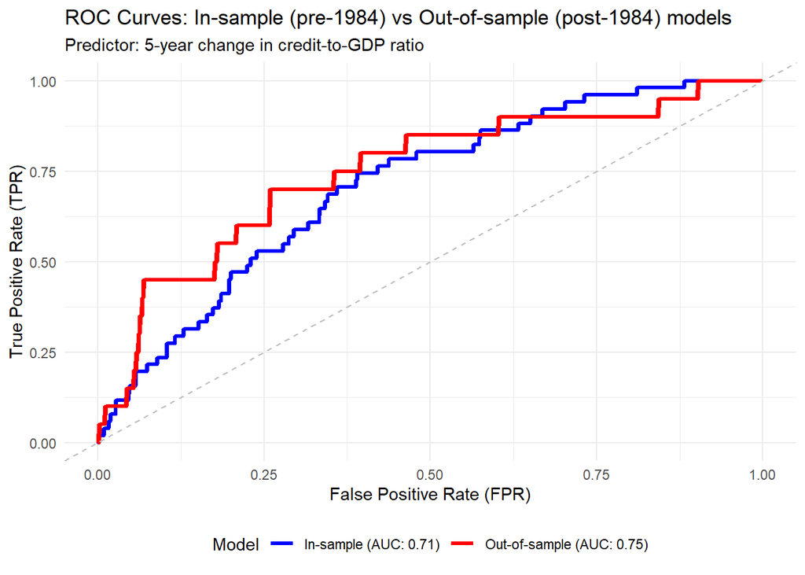

```r
roc_data_in <- data.frame(
  FPR = 1 - roc_in$specificities,
  TPR = roc_in$sensitivities,
  Thresholds = roc_in$thresholds,
  Model = "In-sample (AUC: 0.71)"
)

roc_data_out <- data.frame(
  FPR = 1 - roc_out$specificities,
  TPR = roc_out$sensitivities,
  Thresholds = roc_out$thresholds,
  Model = "Out-of-sample (AUC: 0.75)"
)

roc_data <- rbind(roc_data_in, roc_data_out)

roc_plot <- ggplot(roc_data, aes(x = FPR, y = TPR, color = Model)) +
  geom_line(linewidth = 1.2) +
  labs(title = "ROC Curves: In-sample (pre-1984) vs Out-of-sample (post-1984) models",
       subtitle = "Predictor: 5-year change in credit-to-GDP ratio",
       x = "False Positive Rate (FPR)",
       y = "True Positive Rate (TPR)",
       color = "Model") +
  theme_minimal() +
  theme(legend.position = "bottom") +
  scale_color_manual(values = c("blue", "red")) +
  geom_abline(slope = 1, intercept = 0, linetype = "dashed", color = "gray")

print(roc_plot)
```

Next, we want to repeat the estimation using a) money and b) public debt as predictors.

```r
logit_money = feglm(crisisJST ~ money | country,
                data = jst,
                family = binomial(link = "logit"))
```

```
## NOTE: 200 observations removed because of NA values (LHS: 50, RHS: 200).
```

```r
summary(logit_money)
```

```
## GLM estimation, family = binomial(link = "logit"), Dep. Var.: crisisJST
## Observations: 2,518
## Fixed-effects: country: 18
## Standard-errors: Clustered (country)
##        Estimate Std. Error  z value Pr(>|z|)
## money -1.38e-09   5.67e-10 -2.44033 0.014674 *
## ---
## Signif. codes:  0 '***' 0.001 '**' 0.01 '*' 0.05 '.' 0.1 ' ' 1
## Log-Likelihood: -345.3   Adj. Pseudo R2: -0.024523
##            BIC:  839.5     Squared Cor.:  0.006844
```

The coefficient is negative and is significant at the 5%-level.

```r
logit_debt = feglm(crisisJST ~ debtgdp | country,
                data = jst,
                family = binomial(link = "logit"))
```

```
## NOTE: 229 observations removed because of NA values (LHS: 50, RHS: 229).
```

```r
summary(logit_debt)
```

```
## GLM estimation, family = binomial(link = "logit"), Dep. Var.: crisisJST
## Observations: 2,489
## Fixed-effects: country: 18
## Standard-errors: Clustered (country)
##          Estimate Std. Error  z value Pr(>|z|)
## debtgdp -0.413625   0.405154 -1.02091   0.3073
## ---
## Signif. codes:  0 '***' 0.001 '**' 0.01 '*' 0.05 '.' 0.1 ' ' 1
## Log-Likelihood: -353.1   Adj. Pseudo R2: -0.019778
##            BIC:  854.7     Squared Cor.:  0.007383
```

The coefficient of the debt-to-GDP ratio is negative, but not significant.

Now, plotting the ROC curves. First, we run the predictions for both predictors and create the dataframe required for plotting:

```r
jst$predict_money <- predict(logit_money,
                             newdata = jst,
                             type = "response")

jst$predict_debt <- predict(logit_debt,
                            newdata = jst,
                            type = "response")

roc_money <- roc(jst$crisisJST, jst$predict_money)
auc_money = round(auc(roc_money), 2)

roc_debt <- roc(jst$crisisJST, jst$predict_debt)
auc_debt = round(auc(roc_debt), 2)

roc_moneyvdebt <- rbind(
  data.frame(
    FPR = 1 - roc_money$specificities,
    TPR = roc_money$sensitivities,
    Model = paste("Money Model (AUC:", auc_money, ")")
  ),
  data.frame(
    FPR = 1 - roc_debt$specificities,
    TPR = roc_debt$sensitivities,
    Model = paste("Debt Model (AUC:", auc_debt, ")")
  )
)
```

Finally, we obtain:

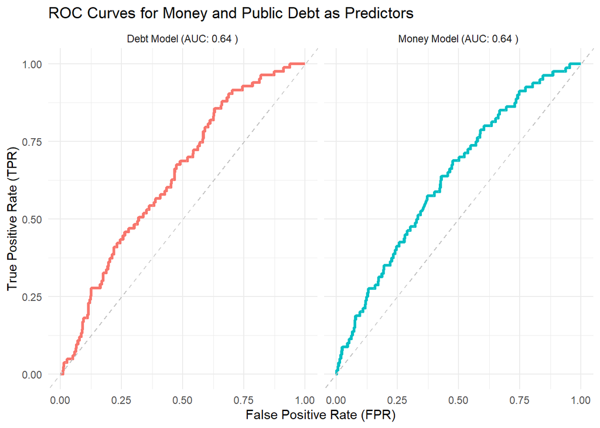

```r
moneyvdebt_plot <- ggplot(roc_moneyvdebt, aes(x = FPR, y = TPR, color = Model)) +
  geom_line(size = 1.2) +
  labs(
    title = "ROC Curves for Money and Public Debt as Predictors",
    x = "False Positive Rate (FPR)",
    y = "True Positive Rate (TPR)"
  ) +
  theme_minimal() +
  geom_abline(slope = 1, intercept = 0, linetype = "dashed", color = "gray") +
  facet_wrap(~ Model) +
  theme(legend.position = "none")

print(moneyvdebt_plot)
```

Let’s recall the previous model for comparison:

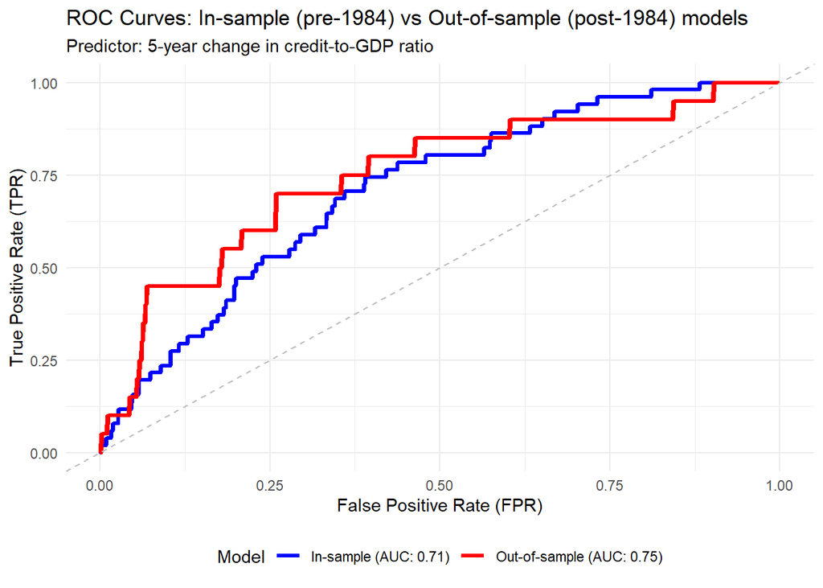

```r
print(roc_plot)
```

The AUC is slightly higher, so using the 5-year change in the credit-to-GDP ratio seems to be the strongest predictor.

## Part B

First, we reload the required datasets.

```r
jst = read_xlsx("C:/Users/etien/OneDrive/Documents/GitHub/Econ-History/A2/JSTdatasetR6.xlsx")

dummies = read_dta("C:/Users/etien/OneDrive/Documents/GitHub/Econ-History/A2/RecessionDummies.dta")
```

First, I check for which countries and years data is available in both datasets.

```r
jst_obs <- jst %>%
  dplyr::select(year, iso) %>%
  distinct() %>%
  arrange(iso, year)

print(jst_obs)
```

```
## # A tibble: 2,718 × 2
##     year iso
##    <dbl> <chr>
##  1  1870 AUS
##  2  1871 AUS
##  3  1872 AUS
##  4  1873 AUS
##  5  1874 AUS
##  6  1875 AUS
##  7  1876 AUS
##  8  1877 AUS
##  9  1878 AUS
## 10  1879 AUS
## # ℹ 2,708 more rows
```

```r
recession_obs <- dummies %>%
  dplyr::select(year, iso) %>%
  distinct() %>%
  arrange(iso, year)

print(recession_obs)
```

```
## # A tibble: 2,448 × 2
##     year iso
##    <dbl> <chr>
##  1  1870 AUS
##  2  1871 AUS
##  3  1872 AUS
##  4  1873 AUS
##  5  1874 AUS
##  6  1875 AUS
##  7  1876 AUS
##  8  1877 AUS
##  9  1878 AUS
## 10  1879 AUS
## # ℹ 2,438 more rows
```

Before merging, I filter the JST data until 2013 to match with the observations of dummies.

```r
jst_filtered <- jst %>%
  filter(year <= 2013)

jst_dummies <- jst_filtered %>%
  left_join(dummies, by = c("iso", "year"))

head(jst_dummies)
```

```
## # A tibble: 6 × 61
##    year country iso     ifs   pop rgdpmad rgdpbarro rconsbarro   gdp    iy   cpi
##   <dbl> <chr>   <chr> <dbl> <dbl>   <dbl>     <dbl>      <dbl> <dbl> <dbl> <dbl>
## 1  1870 Austra… AUS     193  1775   3273.      13.8       21.4  209. 0.109  2.71
## 2  1871 Austra… AUS     193  1675   3299.      13.9       19.9  212. 0.105  2.67
## 3  1872 Austra… AUS     193  1722   3553.      15.0       21.1  227. 0.130  2.54
## 4  1873 Austra… AUS     193  1769   3824.      16.2       23.3  267. 0.125  2.54
## 5  1874 Austra… AUS     193  1822   3835.      16.3       23.5  288. 0.142  2.67
## 6  1875 Austra… AUS     193  1874   4138.      17.6       25.7  301. 0.161  2.75
## # ℹ 50 more variables: ca <dbl>, imports <dbl>, exports <dbl>, narrowm <dbl>,
## #   money <dbl>, stir <dbl>, ltrate <dbl>, hpnom <dbl>, unemp <dbl>,
## #   wage <dbl>, debtgdp <dbl>, revenue <dbl>, expenditure <dbl>, xrusd <dbl>,
## #   tloans <dbl>, tmort <dbl>, thh <dbl>, tbus <dbl>, bdebt <dbl>, lev <dbl>,
## #   ltd <dbl>, noncore <dbl>, crisisJST <dbl>, crisisJST_old <dbl>, peg <dbl>,
## #   peg_strict <dbl>, peg_type <chr>, peg_base <chr>, JSTtrilemmaIV <dbl>,
## #   eq_tr <dbl>, housing_tr <dbl>, bond_tr <dbl>, bill_rate <dbl>, …
```

As the number of rows remains intact after the merge, I conclude that the merge was successful.

```r
jst_dummies <- jst_dummies %>%
  mutate(rgdp = (gdp/cpi))

jst_dummies <- jst_dummies %>%
  mutate(rgdp_pc = rgdp/cpi)

jst_dummies <- jst_dummies %>%
  mutate(
    delta_gdp_1 = rgdp_pc - lag(rgdp_pc, 1),
    delta_gdp_2 = rgdp_pc - lag(rgdp_pc, 2),
    delta_gdp_3 = rgdp_pc - lag(rgdp_pc, 3),
    delta_gdp_4 = rgdp_pc - lag(rgdp_pc, 4),
    delta_gdp_5 = rgdp_pc - lag(rgdp_pc, 5)
  ) %>%
  ungroup()
```

```r
#results_panel <-  lp_lin_panel(data_set = jst_dummies,
#                               endog_data = "rgdp_pc",
#                               cumul_mult = TRUE,
#                               shock = "F" & "N",
#                               diff_shock = TRUE,
#                               panel_model = "within",
#                               panel_effect = "individual",
#                               robust_cov = "vcovSCC",
#                               c_exog_data       = "cay",
#                               l_exog_data       = "cay",
#                               lags_exog_data    = 2,
#                               c_fd_exog_data    = colnames(data_set)[c(seq(4,9),11)],
#                               l_fd_exog_data    = colnames(data_set)[c(seq(3,9),11)],
#                               lags_fd_exog_data = 2,
#                               confint           = 1.67,
#                               hor               = 5)


#plot(results_panel)
```